# Using Modern Box Office Trends to Predict the Financial Success of a Film

## Devin Popa and Noah Bathras

### Introduction

In attempts to make movies bigger, more exciting, and innovative, budgets for Hollywood productions and independent films alike are increasing. This measn that movies which find success through brand-name recognition or word of mouth and/or viral marketing campaigns have the opportunity to earn a lot of money if they make their budget back. On the other hand, movies that fail to break even appear to fail more spectacularly than they had in years past. While it is a binary scale that is not completely indicative of a movie's success, for the purposes of this tutorial, we will define a movie's success based on whether or not it grossed enough money in total to earn its budget back for the sake of simplicity.

Building on this definition, we will examine the business side of movies through data analysis and various machine learning algorithms to make an attempt to predict whether or not movies will be successful. Our models will consider a film's distribution studio, release date, MPAA rating, and genre from movies released between the years of 2015 and 2018 to see whether or not a film is likely to make its budget back. Prior to this, we will be collecting and tidying the information we gather from our data source and graphing plots for noteworthy trends between the previously mentioned factors and film box office gross.

While such an analysis might only seem useful for the people involved in the production of films, avid moviegoers can take away a lot of information from this as well. It is natural to assume that movie studios will continue to endorse projects that are known to be popular or well-received, and they may be less open to doing the same for unknown quantities. Going by this, people who are interested can theorize the types of films that will be released in the recent future. Finally, those that are interested in creating their own films may get a better sense of what types of movies are "safe bets" among audiences, and which ones may be riskier.

### Limitations

Before beginning this tutuorial, we should discuss some limitations of our analysis. As our previous definition of success would suggest, we do not take critical recpetion or word-of-mouth as factors for our machine learning models. Part of this could be alleviated by using the Twitter API to count the number of times a hashtag associated with a movie was used during its theatrical run, but this would not determine the positive or negative valence of the tweets being examined. It should also be noted that we are only looking at films released from 2015 to 2018, so a larger sample of data, or a different subset of movie data across four years, may yield different results than the ones found here.

### Importing Necessary Packages

First, we will need to import all of the required packages in order to collect and perform analysis on the data. BeautifulSoup, requests, html5lib, and lxml will all be used to scrape the web data. Pandas and numpy are necessary for storing and manipulating the data as needed. In order to produce visualizations of our findings, we will use matplotlib and seaborn. Finally, scikit learn will be used to implement each of the models that we test

```python
# required packages and setup variables
from bs4 import BeautifulSoup
import seaborn as sns
import pandas as pd
import numpy as np
import requests
import html5lib
import lxml     # open a new terminal and pip install lxml before running
import matplotlib.pyplot as plt
import matplotlib as mpl

import sklearn
from sklearn.kernel_ridge import KernelRidge
from sklearn.model_selection import KFold
from sklearn import linear_model
from sklearn.linear_model import LinearRegression
from sklearn.model_selection import train_test_split
from sklearn.linear_model import LogisticRegression
from sklearn import svm
from sklearn.neighbors import KNeighborsClassifier
from sklearn.ensemble import RandomForestClassifier

import warnings
# Suppress Warning
warnings.filterwarnings(action="ignore", module="scipy", message="^internal gelsd")
warnings.simplefilter(action='ignore', category=FutureWarning)
np.warnings.filterwarnings('ignore')
```

### Data Collection

All of the data that we have collected comes from https://www.the-numbers.com/, a website that manages a large database of movies and creates tables for different sets of properties and films. For example, the domestic gross information for movies screened in 2018 can be found here: https://www.the-numbers.com/market/2018/top-grossing-movies. To find the information for each year between 2015 and 2018, we first created a function that would scrape data from a single web page. We store the data into an object called a DataFrame, which can be thought of as the Pandas equivalent to a table.

```python
def getSingleYearAnnualTopGrossingMovies(url):
    # Make a web request to the url parameter
    req = requests.get(url)
    req.encoding = 'utf-8' # guarantees movie titles are displayed correctly
    soup = BeautifulSoup(req.text)

    # Remove all links/tags from the entries
    table = soup.find('table')
    for a in table.findAll('a'):
        a.replaceWithChildren()

    # Create a new DataFrame from the table variable
    df_list = pd.read_html(str(table))
    movie_df = df_list[0]
    movie_df.columns = ['rank', 'movie', 'releaseDate', 'distributor',
                        'genre', 'rating', 'domesticGross', 'ticketsSold']
    movie_df = movie_df.drop([0])     # drop the first row, does not include data
    movie_df = movie_df[:-2]     # drop the last two rows, contain aggregate data
    # removes any rows that do not have data in them
    movie_df = movie_df.dropna()

    return movie_df
```

The next function builds on the previous one by getting all of the domestic gross information we are looking for. The previous function is used to get data for every year that we are looking at, and the concat function is used to put all of this information into a single DataFrame. The reset_index function is used to maintain a sequential ordering of the data after the concatenation operation.

```python
# Compiles Top Gorssing Domestic Movies From 2015-2018
# The Domestic Market is defined as the North American movie territory (consisting of the United States, Canada,
#   Puerto Rico and Guam).
def getAllAnnualTopGrossingMovies():
    movie_df_2018 = getSingleYearAnnualTopGrossingMovies(url='https://www.the-numbers.com/market/2018/top-grossing-movies')
    movie_df_2017 = getSingleYearAnnualTopGrossingMovies(url='https://www.the-numbers.com/market/2017/top-grossing-movies')
    movie_df_2016 = getSingleYearAnnualTopGrossingMovies(url='https://www.the-numbers.com/market/2016/top-grossing-movies')
    movie_df_2015 = getSingleYearAnnualTopGrossingMovies(url='https://www.the-numbers.com/market/2015/top-grossing-movies')
    movie_df = pd.concat([movie_df_2018, movie_df_2017, movie_df_2016, movie_df_2015], sort=False)
    movie_df = movie_df.reset_index(drop=True)

    return movie_df
```

Now that we are done scraping the gross data for each year, we need to collect data on the budgets of these movies. The budget data (found at https://www.the-numbers.com/movie/budgets/all) that this site gives operates differently than the domestic gross data. Instead of creating separate tables for each year, the budget data is a large data table that contains movies from any year separated into pages that each contain 100 entries. We start with the base page of budget data and perform a similar process of collecting data seen for the gross web pages, with an additional step of tidying the data in order to convert all of the monetary information from strings to integer values. This will make it easier to make comparisons between movies for each of these values and make later analysis easier.

```python
# Request to initial budget data
def getMovieBudgetData():
    req = requests.get('https://www.the-numbers.com/movie/budgets/all')
    req.encoding = 'utf-8'
    soup = BeautifulSoup(req.text)

    # Create new DataFrame in i similar process as before
    table = soup.find('table')
    for a in table.findAll('a'):
        a.replaceWithChildren()

    df_list = pd.read_html(str(table))
    budget_df = df_list[0]
    budget_df.columns = ['id', 'releaseDate', 'movie', 'budget', 'domesticGross', 'totalGross']
    budget_df = budget_df.drop(['id', 'domesticGross'], axis=1)    # drop id column
    budget_df = budget_df.drop([0])    # drop one unnecessary row
    budget_df = budget_df.dropna()     # drop any missing data

    # Conversion of moonetary values given as strings to integers
    budgetConvert = []
    totalGrossConvert = []
    for index, row in budget_df.iterrows():
        converted_budget = int(row["budget"][1:].replace(",", ""))
        budgetConvert.append(converted_budget)
        converted_total = int(row['totalGross'][1:].replace(',', ''))
        totalGrossConvert.append(converted_total)
    budget_df["budget"] = budgetConvert
    budget_df['totalGross'] = totalGrossConvert

    # Store additional numbers as strings that will help link to each additional page
    # of 100 entries
    pages = []
    index = 101
    while index <= 5601:
        pages.append(str(index))
        index += 100

    # Repeat previous steps in retrieving budget data, but with additional entries that have separate links
    # WARNING: Causes long load times when recollecting the data
    for index in pages:
        req = requests.get('https://www.the-numbers.com/movie/budgets/all' + '/' + index)
        req.encoding = 'utf-8'
        soup = BeautifulSoup(req.text)

        table = soup.find('table')
        for a in table.findAll('a'):
            a.replaceWithChildren()

        df_list = pd.read_html(str(table))
        other_budget_df = df_list[0]
        other_budget_df.columns = ['id', 'releaseDate', 'movie', 'budget', 'domesticGross', 'totalGross']
        other_budget_df = other_budget_df.drop(['id', 'domesticGross'], axis=1)    # drop id column
        other_budget_df = other_budget_df.drop([0])     # drop one unnecessary row
        other_budget_df = other_budget_df.dropna()     # drop any missing data


        budgetConvert = []
        totalGrossConvert = []
        for index, row in other_budget_df.iterrows():
            converted_budget = int(row["budget"][1:].replace(",", ""))
            budgetConvert.append(converted_budget)
            converted_total = int(row['totalGross'][1:].replace(',', ''))
            totalGrossConvert.append(converted_total)
        other_budget_df["budget"] = budgetConvert
        other_budget_df['totalGross'] = totalGrossConvert

        budget_df = budget_df.append(other_budget_df)

    # New DataFrame containing budget and worldwide gross (not just domestic, unlike previous dataframe)
    # information for a large selection of movies
    return budget_df
```

### Tidying The Data

Now that we have collected all of the data we will be using, the next step is to further prepare it for analysis by making small adjustments. The first of these is to combine the two separate dataframes for gross and budget information into one. We achieve this through an inner join, which means that any movies that are in one table but not the other will not be added to the combined dataframe. In a later step, we will change this process to use a left join, which combines the two tables based on the movies found in the movie DataFrame. It is worth noting that a left join can lead to missing values in the combined DataFrame. An example of the different types of join operations that can be performed, as well as a visual representation of these types, can be found here: https://www.shanelynn.ie/merge-join-dataframes-python-pandas-index-1/.

```python
# Combines the movie_df dataframe with the budget dataframe using a left join.
def combineMovieAndBudgetDF(movie_df, budget_df, how='inner'):
    movie_df = movie_df.merge(budget_df, on=['movie', 'releaseDate'], how=how)
    return movie_df
```

After joining our two datasets together, we need to perform a few more numeric conversions on the rank of a film's gross (from highest to lowest), the number of tickets a film sold, and its annual domestic gross. Additionally, we split the release date for each film by month and year so that we can perform comparisons between a movie's domestic gross and both the month and year it was released.

```python
# Final reformat of the data
def reformatData(movie_df):
    domesticGrossConvert = []
    monthList = []
    yearList  = []
    for index, row in movie_df.iterrows():
        # converts annual gross to a number
        converted_string = int(row["domesticGross"][1:].replace(",", ""))
        domesticGrossConvert.append(converted_string)

        # converts dates to two columns and numbers
        month_int = int(row["releaseDate"].split("/")[0])
        monthList.append(month_int)
        year_int  = int(row["releaseDate"].split("/")[2])
        yearList.append(year_int)
    movie_df["releaseMonth"]  = monthList
    movie_df["releaseYear"]   = yearList
    movie_df["domesticGross"] = domesticGrossConvert

    # converts ticketsSold to numbers
    movie_df["ticketsSold"] = pd.to_numeric(movie_df["ticketsSold"])

    # converts rank to numbers
    movie_df["rank"] = pd.to_numeric(movie_df["rank"])

    # sorts based on rank
    movie_df = movie_df.sort_values(by=['rank'])

    # resets index values again
    movie_df = movie_df.reset_index(drop=True)

    return movie_df
```

The next step is to "pickle" the dataframe that is collected by all of the functions defined above. This refers to saving the variable movie_df to the project folder, and this bypasses having to wait for the long loading times of scraping all of the web pages every time we run the program. If the variable is_load_dataframe is set to True, then the dataframe is loaded from what is found in the project folder. Otherwise, all of the previously defined functions are called to create the dataframe, which is then added to the project folder.

```python
# Pickeling or unpickling the data
is_load_dataframe = True

movie_df      = None
movei_df_long = None
if is_load_dataframe:
    movie_df_long  = pd.read_pickle("./movie_df_long")
    movie_df_short = pd.read_pickle("./movie_df_short")
else:
    movie_df        = getAllAnnualTopGrossingMovies()
    budget_df       = getMovieBudgetData()
    movie_df_short  = combineMovieAndBudgetDF(movie_df, budget_df, how="inner")
    movie_df_long   = combineMovieAndBudgetDF(movie_df, budget_df, how="left")
    movie_df_short  = reformatData(movie_df_short)
    movie_df_long   = reformatData(movie_df_long)

    movie_df_long.to_pickle("./movie_df_long")
    movie_df_short.to_pickle("./movie_df_short")

print("Num movies make back budget in domestic: " + str(movie_df_short.loc[movie_df_short['domesticGross'] > movie_df_short['budget']].shape[0]))
print("Num movies make back budget in world: " + str(movie_df_short.loc[movie_df_short['totalGross'] > movie_df_short['budget']].shape[0]))
print("Total movies " + str(movie_df_short.shape[0]))
```

```
Num movies make back budget in domestic: 310
Num movies make back budget in world: 601
Total movies 767
```

### Data Visualization

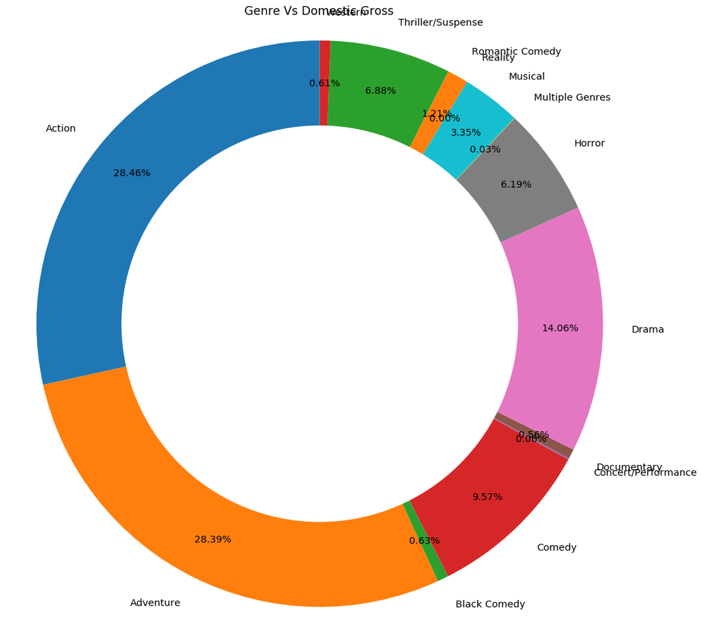

```python
grouped = movie_df_long.groupby(['genre'])['domesticGross'].sum()
# will produce the exact same graph
# grouped = movie_df.groupby(['genre'])['ticketsSold'].sum()

labels = grouped.index.tolist()
values = grouped.tolist()
explode = [0.0] * len(labels)

mpl.rcParams['font.size'] = 13.0
fig1, ax1 = plt.subplots(figsize=(12,12), dpi=80)
ax1.set_title('Genre Vs Domestic Gross')

ax1.pie(values, labels=labels, autopct='%1.2f%%', startangle=90, pctdistance=0.85, explode = explode)
#draw circle
centre_circle = plt.Circle((0,0),0.70,fc='white')
fig = plt.gcf()
fig.gca().add_artist(centre_circle)
# Equal aspect ratio ensures that pie is drawn as a circle
ax1.axis('equal')
plt.tight_layout()
plt.show()
```

The following plot displays the average gross of a movie given its genre, and it allows us it to gain some insights into the previous pie chart. As expected, action and adventure movies once again dominate. However, an interesting realization is made when seeing that the third highest average gross is for the genre of musical films. In fact, whereas drama films made up the third largest portion of the sum of domestic gross for movies, they are on average going to be the fifth lowest grossing type of movie. What this shows us is that the market is saturated with drama films when compared to movies of other genres. Additionally, the claim made that niche genres of movies aren't doing well for total gross, as is the case with black comedies and westerns, is given more credibility by this bar graph.

```
genre
Action                 5.610675e+07
Adventure              7.074821e+07
Black Comedy           7.704951e+06
Comedy                 1.226423e+07
Concert/Performance    4.737559e+06
Documentary            4.726068e+05
Drama                  6.107918e+06
Horror                 2.407778e+07
Multiple Genres        1.217966e+06
Musical                4.642054e+07
Reality                1.517242e+05
Romantic Comedy        6.951746e+06
Thriller/Suspense      1.256380e+07
Western                9.702466e+06
Name: domesticGross, dtype: float64
```

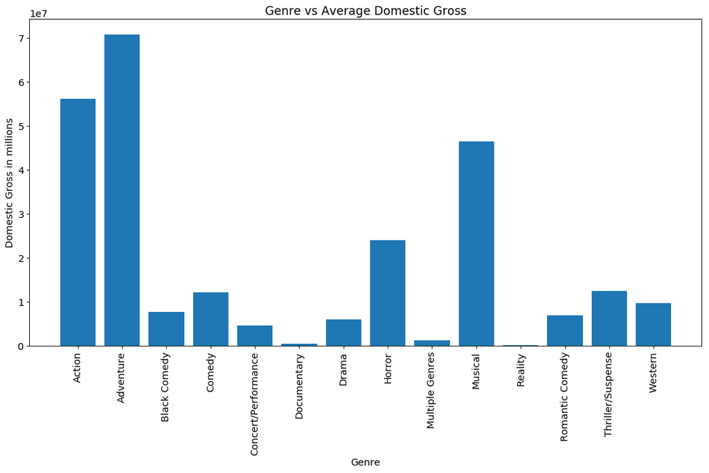

```python
grouped = movie_df_long.groupby(['genre'])['domesticGross'].mean()

print(grouped)

x = np.array(grouped.index.tolist())
y = np.array(grouped.tolist())

fig1, ax1 = plt.subplots(figsize=(16,8), dpi=80)
ax1.set_title('Genre vs Average Domestic Gross')

ax1.bar(x, y)
plt.xticks(rotation='vertical')
plt.xlabel('Genre')
plt.ylabel('Domestic Gross in millions')
plt.show()
```

```
rating
G            1.003768e+07
GP           5.292700e+04
NC-17        1.776350e+04
Not Rated    2.698582e+05
PG           4.349002e+07
PG-13        4.390365e+07
R            1.305596e+07
Name: domesticGross, dtype: float64
```

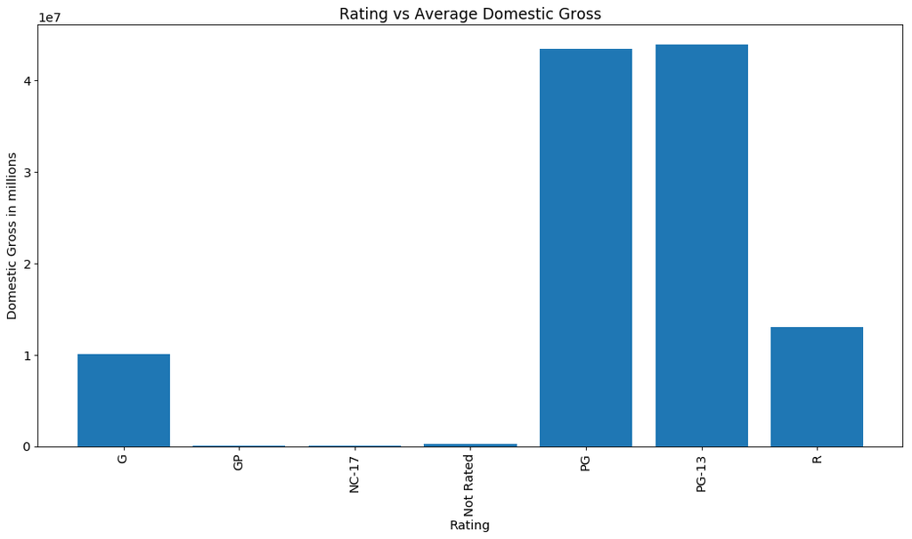

```python
grouped = movie_df_long.groupby(['rating'])['domesticGross'].mean()

print(grouped)

x = np.array(grouped.index.tolist())
y = np.array(grouped.tolist())

fig1, ax1 = plt.subplots(figsize=(16,8), dpi=80)
ax1.set_title('Rating vs Average Domestic Gross')

ax1.bar(x, y)
plt.xticks(rotation='vertical')
plt.xlabel('Rating')
plt.ylabel('Domestic Gross in millions')
plt.show()
```

The final two pie charts display movie ratings vs total domestic gross and movie ratings vs total number of movies made, respectively. The most dramatic and surprising difference betwen these two plots is that more than 43% of films being made are Not Rated, but they only account for 0.75% of total gross among movies. Contrary to this, movies that are rated either PG or PG-13 are created with much lower frequency, but these two ratings combined comprise nearly 75% of the total domestic gross for films. Movies that were rated G or R did not see as significant of a change between the amount of movies being made and the domestic earnings in terms of the percentage of each between both pie charts. Similar to drama films in the analysis of genre, we see more clearly that movies that are Not Rated are oversaturating the market.

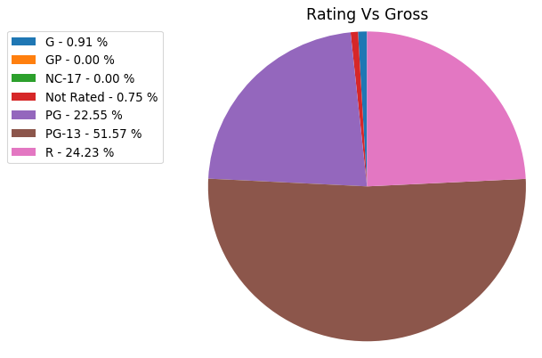

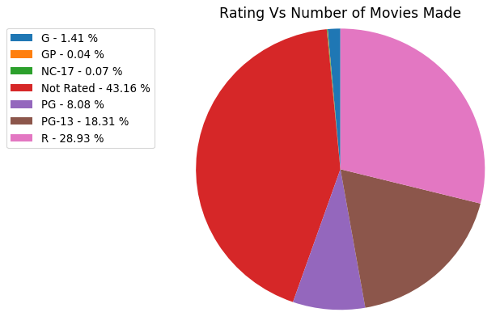

```python
grouped = movie_df_long.groupby(['rating'])['domesticGross'].sum()

x = np.char.array(grouped.index.tolist())
y = np.array(grouped.tolist())
percent = 100.*y/y.sum()

fig1, ax1 = plt.subplots(figsize=(6,6), dpi=80)
ax1.set_title('Rating Vs Gross')

patches, texts = ax1.pie(y, startangle=90, radius=1.2)
labels = ['{0} - {1:1.2f} %'.format(i,j) for i,j in zip(x, percent)]

plt.legend(patches, labels, bbox_to_anchor=(-0.1, 1.), fontsize=12)
plt.show()

grouped = movie_df_long.groupby(['rating'])['domesticGross'].count()

x = np.char.array(grouped.index.tolist())
y = np.array(grouped.tolist())
percent = 100.*y/y.sum()

fig1, ax1 = plt.subplots(figsize=(6,6), dpi=80)
ax1.set_title('Rating Vs Number of Movies Made')

patches, texts = ax1.pie(y, startangle=90, radius=1.2)
labels = ['{0} - {1:1.2f} %'.format(i,j) for i,j in zip(x, percent)]

plt.legend(patches, labels, bbox_to_anchor=(-0.1, 1.), fontsize=12)
plt.show()
```

The final piece of information we wil be looking at within visualization is release time regarding month, and how that may impact the success of a movie. We see that the average film is the most successful when it is released in June, July, or December. This may have some overlap with the results of the ratings plots, teenagers have more free time during summer break and the holiday season to watch movies, and the most highest earning films are, on average, rated PG-13. These also happen to be the times where large studios release their major blockbuster movies, most likely because of the previous reason. In contrast to this, movies are most likely to earn the least money if they are released in either October or January. This is likely the case for the month of October due to the fact that horror movies start to have a greater presence on the market as Halloween approaches, and horror as a genre has a smaller general audience associated with it than ones like drama, action, or adventure. For January, I hypothesize that the lower average gross is caused by teenagers returning to school after their winter breaks.

```
releaseMonth
1     8.998238e+06
2     1.807925e+07
3     1.661137e+07
4     1.272692e+07
5     1.822603e+07
6     2.510844e+07
7     2.341425e+07
8     1.158470e+07
9     9.103964e+06
10    7.555153e+06
11    1.780681e+07
12    2.133547e+07
Name: domesticGross, dtype: float64
```

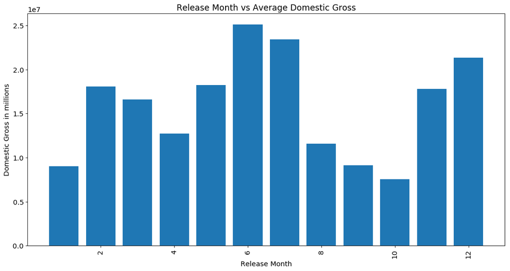

```python
grouped = movie_df_long.groupby(['releaseMonth'])['domesticGross'].mean()

print(grouped)

x = np.array(grouped.index.tolist())
y = np.array(grouped.tolist())

fig1, ax1 = plt.subplots(figsize=(16,8), dpi=80)
ax1.set_title('Release Month vs Average Domestic Gross')

ax1.bar(x, y)
plt.xticks(rotation='vertical')
plt.xlabel('Release Month')
plt.ylabel('Domestic Gross in millions')
plt.show()
```

### Creating Feature Lists

Now that we have the data in a form that allows for comparisons between different pieces of information, we can start analyzing a movie's chance of success based on these criteria. We will start by defining our feature lists, which consist of genre, rating, distributor, release month and year, domestic gross, and budget. To start, we create a dictionary for each categorical attribute. Then, for every unique value of an entry in the DataFrame, we add a key to the corresponding attribute DataFrame for that possibility, and its associated value is a list of numbers equal to the number of total entries in the DataFrame. The list is initialized to zeros. For quantitative attributes, we skip the creation of the dictionary and use a list initialized to all zeros for every row of the DataFrame.

```python
def build_default_feature_lists(df):
    num_rows = len(df.index)

    # genre dictionary creation
#     print(movie_df.genre.unique())
    genre_name_list = ['Action', 'Adventure', 'Musical', 'Drama', 'Horror',
                       'Thriller/Suspense', 'Comedy', 'Romantic Comedy', 'Western',
                       'Black Comedy', 'Concert/Performance']
    genre_name_dict = {}

    # Add key for each genre_name to genre_dict
    for genre_name in genre_name_list:
        default_list                = np.zeros(num_rows)
        genre_name_dict[genre_name] = default_list
    default_list             = np.zeros(num_rows)
    genre_name_dict["other"] = default_list

    # rating dictionary creation
#     print(movie_df.rating.unique())
    rating_name_list = ['PG-13', 'PG', 'R', 'G']
    rating_name_dict = {}

    # Add key for each rating to rating_name_dict
    for rating_name in rating_name_list:
        default_list                  = np.zeros(num_rows)
        rating_name_dict[rating_name] = default_list
    default_list              = np.zeros(num_rows)
    rating_name_dict["other"] = default_list

    # distributor dictionary creation
#     print(movie_df.distributor.unique())
    distributor_name_list = list(df.distributor.unique())
    distributor_name_list = distributor_name_list[:20]

    distributor_name_dict = {}

    for distributor_name in distributor_name_list:
        default_list                            = np.zeros(num_rows)
        distributor_name_dict[distributor_name] = default_list
    default_list                   = np.zeros(num_rows)
    distributor_name_dict["other"] = default_list

    # basic list creation
    releaseMonth_list  = np.zeros(num_rows)
    releaseYear_list   = np.zeros(num_rows)

    domesticGross_list = np.zeros(num_rows)
    budget_list        = np.zeros(num_rows)

    return (genre_name_dict, rating_name_dict, distributor_name_dict, releaseMonth_list, releaseYear_list, domesticGross_list, budget_list)
```

The next step is to construct two arrays. X will contain lists for each attribute we want to examine. The values for each list will be the dictionaries defined from the previous function, if we are looking at a qualitative factor, or the list of numbers retrieved for a numeric variable. The exact steps to obtain these arrays are left as comments in the code below, but once we have them, we will be able to examine the accuracy with which this information allows us to predict the success of a movie.

```python
def build_feature_lists(df, is_include_budget=False, is_classification=False):
    genre_name_dict, rating_name_dict, distributor_name_dict, releaseMonth_list, releaseYear_list, domesticGross_list, budget_list = build_default_feature_lists(df)

    counter = 0
    for index, row in df.iterrows():

        # Get value for each category to train on
        domesticGross_value = row["domesticGross"]
        genre_value         = row["genre"]
        distributor_value   = row["distributor"]
        rating_value        = row["rating"]
        releaseMonth_value  = row["releaseMonth"]
        releaseYear_value   = row["releaseYear"]

        # Increment counter for categorical values if a known option was found
        # Otherwise, increment counter for other
        if genre_value in genre_name_dict:
            genre_name_dict[genre_value][counter] = 1
        else:
            genre_name_dict["other"][counter] = 1

        if rating_value in rating_name_dict:
            rating_name_dict[rating_value][counter] = 1
        else:
            rating_name_dict["other"][counter] = 1

        if distributor_value in distributor_name_dict:
            distributor_name_dict[distributor_value][counter] = 1
        else:
            distributor_name_dict["other"][counter] = 1

        # Add numerical data for release month and year as is
        releaseMonth_list[counter] = int(releaseMonth_value)
        releaseYear_list[counter]  = int(releaseYear_value)

        # Get budget value if applicable
        budget_value = None
        if is_include_budget:
            budget_value        = row["budget"]
            budget_list[counter] = int(budget_value)

        # Check for success in earning back budget with domestic gross
        if is_classification:
            if domesticGross_value > budget_value:
                domesticGross_list[counter] = 1
            else:
                domesticGross_list[counter] = 0
        else:
            domesticGross_list[counter] = int(domesticGross_value)

        # Increment the counter and re-enter the loop
        counter = counter + 1

    # Initializes a DataFrame for training data
    df_train_values = pd.DataFrame(releaseMonth_list, columns=["releaseMonth"])

    # Add new column to training DF for each atttribute and subcategory
    # Use the previously defined lists for numerical data
    df_train_values["releaseYear"] = releaseYear_list
    for key, value in genre_name_dict.items():
        column_name = "genre_" + str(key)
        df_train_values[column_name] = value
    for key, value in rating_name_dict.items():
        column_name = "rating_" + str(key)
        df_train_values[column_name] = value
    for key, value in distributor_name_dict.items():
        column_name = "distributor_" + str(key)
        df_train_values[column_name] = value
    df_train_values["domesticGross"] = domesticGross_list
    if is_include_budget:
        df_train_values["budget"] = budget_list

    # Construct X (the categories that we want to examine for correlation)
    # and y (domestic gross, the category that we are examining to measure success)
    # from the data
    counter = 0
    X = None
    y = np.array(df_train_values["domesticGross"])
    prev_column = None
    new_column  = None
    for column in df_train_values:
        if column == "domesticGross":
            continue

        new_column = df_train_values[column]
        new_column = new_column[:,np.newaxis]
        if counter == 0:
            X = new_column
        else:
            X = np.append(X, new_column, 1)
        counter = counter + 1

    return (X,y)
```

### Results of Various Machine Learning Models

Note that we will link external resources to provide more information for each of the machine learning models we have selected. We first define a cross-validation strategy that will be common to all of the tests we perform.

```python
# KFold cross-validation.  Splits data on 10 indices and shuffles each division
a_fold = KFold(10, shuffle=True)
```

The first set of data we will be testing on is the larger of the two sets. We will not be including budget data, as some of the data is missing from the left join process mentioned before, and we will only be trying to look at the degree of the relationship between our independent variables and a film's domestic gross. For these tests, we will not be looking at the accuracy of our models.

```python
X, y = build_feature_lists(movie_df_long, is_include_budget=False, is_classification=False)
```

#### Test 1 - Linear Regression (Left Join)

The goal of linear regression is to model two variables X and y by an equation of the form y = mX + b, where X and y correspond to the feature lists that were created prior to testing. Further information: https://www.statisticssolutions.com/what-is-linear-regression/

```python
model = LinearRegression()
cross_val_scores = sklearn.model_selection.cross_val_score(model, X, y, cv=a_fold, scoring='r2')
print("Linear Regression Results: ")
print("Mean of Accuracy Score: " + str(cross_val_scores.mean()))
print("Std of Accuracy Score: " + str(cross_val_scores.std()))
```

```
Linear Regression Results:
Mean of Accuracy Score: 0.359633827882
Std of Accuracy Score: 0.119709143009
```

We can interpret the results of this test and the following ones by examining the mean of the accuracy score. This result tells us that nearly 36% of the data relating our independent variables (genre, rating, release date, etc.) to the dependent variable of domestic gross can be explained by our linear model. In other words, a linear model is not well-suited for explaining correlation between the variables we are looking at to measure a film's ability to earn back its budget. For this dataset, we will try two other fit models to see if we get similar results: ridge regression and kernel ridge regression.

#### Test 2 - Ridge Regression (Left Join)

Ridge regression works similarly to linear regression testing. The key difference between the two is that ridge regression testing eliminates collinearity, or nearly linear relationships between independent variables, by adding a degree of bias to the estimates. More information: https://ncss-wpengine.netdna-ssl.com/wp-content/themes/ncss/pdf/Procedures/NCSS/Ridge_Regression.pdf.

```python
model = linear_model.Ridge(alpha=.5)
cross_val_scores = sklearn.model_selection.cross_val_score(model, X, y, cv=a_fold, scoring='r2')
print("Linear Regression Ridge Results: ")
print("Mean of Accuracy Score: " + str(cross_val_scores.mean()))
print("Std of Accuracy Score: " + str(cross_val_scores.std()))
```

```
Linear Regression Ridge Results:
Mean of Accuracy Score: 0.368989682958
Std of Accuracy Score: 0.0983811560478
```

We see a slightly stronger relationship than we did in the linear regression model, but the difference is not significant.

#### Test 3 - Kernel Ridge Regression (Long)

The kernel ridge regression model diverges from the regular ridge regression one by replacing instances of data with its feature vector. An in depth mathematical explanation of this difference can be found here: https://www.ics.uci.edu/~welling/classnotes/papers_class/Kernel-Ridge.pdf.

```python
model = KernelRidge(alpha=1.0)
cross_val_scores = sklearn.model_selection.cross_val_score(model, X, y, cv=a_fold, scoring='r2')
print("Kernel Ridge Results: ")
print("Mean of Accuracy Score: " + str(cross_val_scores.mean()))
print("Std of Accuracy Score: " + str(cross_val_scores.std()))
```

```
Kernel Ridge Results:
Mean of Accuracy Score: 0.357635288079
Std of Accuracy Score: 0.113947613252
```

All in all, the three tests performed for the left-joined DataFrame have been nearly equally inaccurate. This could be a weakness in the relative simplicity in all of the models used here, but this may also be due to the fact that the version of the DataFrame used here includes missing data entries, and thus inaccuracy is more likely to occur. To test this hypothesis, we will try the same three models on the DataFrame with which an inner join was used to combine movie and budget data. Furthermore, we will be including film budget as an independent variable when testing for correlation.

```python
X, y = build_feature_lists(movie_df_short, is_include_budget=True, is_classification=False)
```

#### Test 4 - Linear Regression (Short)

```python
model = LinearRegression()
cross_val_scores = sklearn.model_selection.cross_val_score(model, X, y, cv=a_fold, scoring='r2')
print("Linear Regression Results: ")
print("Mean of Accuracy Score: " + str(cross_val_scores.mean()))
print("Std of Accuracy Score: " + str(cross_val_scores.std()))
```

```
Linear Regression Results:
Mean of Accuracy Score: 0.27117708712
Std of Accuracy Score: 0.229951171908
```

If anything, it appears that, from this initial linear regression test on our more concdensed set of data, adding budget as an independent variable makes the linear relationship less strong.

#### Test 5 - Ridge Regression (Short)

```python
model = linear_model.Ridge(alpha=.5)
cross_val_scores = sklearn.model_selection.cross_val_score(model, X, y, cv=a_fold, scoring='r2')
print("Linear Regression Ridge Results: ")
print("Mean of Accuracy Score: " + str(cross_val_scores.mean()))
print("Std of Accuracy Score: " + str(cross_val_scores.std()))
```

```
Linear Regression Ridge Results:
Mean of Accuracy Score: 0.344507438465
Std of Accuracy Score: 0.128829820138
```

#### Test 6 - Kernel Ridge Regression (Short)

```python
model = KernelRidge(alpha=1.0)
cross_val_scores = sklearn.model_selection.cross_val_score(model, X, y, cv=a_fold, scoring='r2')
print("Kernel Ridge Results: ")
print("Mean of Accuracy Score: " + str(cross_val_scores.mean()))
print("Std of Accuracy Score: " + str(cross_val_scores.std()))
```

```
Kernel Ridge Results:
Mean of Accuracy Score: 0.276594705845
Std of Accuracy Score: 0.0949143608922
```

Across each of the different models for the two sets, the linear coefficients are smaller for the shorter dataset with a newly introduced independent variable than they are for the previous conditions. Now we will examine the accuracy of classification of whether or not a movie is successful by our guideline by using four different classification techniques: logistic regression, support vector classification (SVC), K nearest neighbors classification, and a random forest classifier.

```python
X, y = build_feature_lists(movie_df_short, is_include_budget=True, is_classification=True)
```

#### Test 7 - Linear Regression (Short, Classification)

```python
model = LinearRegression()
cross_val_scores = sklearn.model_selection.cross_val_score(model, X, y, cv=a_fold, scoring='r2')
print("Linear Regression Results: ")
print("Mean of Accuracy Score: " + str(cross_val_scores.mean()))
print("Std of Accuracy Score: " + str(cross_val_scores.std()))
```

```
Linear Regression Results:
Mean of Accuracy Score: 0.0970877137151
Std of Accuracy Score: 0.0977593387095
```

#### Test 8 - Ridge Regression (Short, Classification)

```python
model = linear_model.Ridge(alpha=.5)
cross_val_scores = sklearn.model_selection.cross_val_score(model, X, y, cv=a_fold, scoring='r2')
print("Linear Regression Ridge Results: ")
print("Mean of Accuracy Score: " + str(cross_val_scores.mean()))
print("Std of Accuracy Score: " + str(cross_val_scores.std()))
```

```
Linear Regression Ridge Results:
Mean of Accuracy Score: 0.0891940067247
Std of Accuracy Score: 0.11442519206
```

Once again, we see that linear models are wildly inaccurate and do not do a good job of explaining the tendencies of the data. In fact, given the classification option, the models are now at their least accurate. This provides us with more than enough evidence that linear models cannot properly determine the relationships between a film's various features and its performance at the box office. We will now look at different classification methods to determine whether or not a film will financially succeed during its theatrical run.

#### Test 9 - Logistic Regression Classification

Logistic regression classification is used for binary classification problems, which would be whether or not a movie earns its budget back in the case of this tutorial. It uses the sigmoid function to shift the range of data so that it all falls between 0 and 1. The following blog post goes more in depth about the function used to make this transformation: https://machinelearningmastery.com/logistic-regression-for-machine-learning/.

```python
model = LogisticRegression(random_state=0, solver='lbfgs', multi_class='multinomial')
cross_val_scores = sklearn.model_selection.cross_val_score(model, X, y, cv=a_fold, scoring='accuracy')
print("Logistic Regression Results: ")
print("Mean of Accuracy Score: " + str(cross_val_scores.mean()))
print("Std of Accuracy Score: " + str(cross_val_scores.std()))
```

```
Logistic Regression Results:
Mean of Accuracy Score: 0.595864661654
Std of Accuracy Score: 0.0506523023668
```

When testing the accuracy of our model, we see that it has almost a 60% chance to correctly determine whether or not a movie will break even at the box office. While this is not much better than a random guess, it is still proving to be far more accurate than a linear model could.

#### Test 10 - Support Vector Machine (SVM)

A support vector machine performs classification by modeling data with binary classification in two-dimensional space and finding the line which best divides the categories of data. Source: https://medium.com/machine-learning-101/chapter-2-svm-support-vector-machine-theory-f0812effc72.

```python
model = svm.SVC(gamma=0.001)
cross_val_scores = sklearn.model_selection.cross_val_score(model, X, y, cv=a_fold, scoring='accuracy')
print("Support Vector Machines Results: ")
print("Mean of Accuracy Score: " + str(cross_val_scores.mean()))
print("Std of Accuracy Score: " + str(cross_val_scores.std()))
```

```
Support Vector Machines Results:
Mean of Accuracy Score: 0.565755297334
Std of Accuracy Score: 0.0439058900561
```

#### Test 11 - K Nearest Neighbors

With the K nearest neighbors classifier, we are looking at the two nearest neighbors of a piece of data, and classifying it based on the classifications of the neighbors. To find the nearest neighbors, we use the K-d tree method that is considered by default with the sci-kit learn implementation. For more information on different ways of selecting the nearest neighbors, or a more detailed explanation of the algorithm, see the following: https://medium.com/machine-learning-101/k-nearest-neighbors-classifier-1c1ff404d265.

```python
model = KNeighborsClassifier(n_neighbors=2)
cross_val_scores = sklearn.model_selection.cross_val_score(model, X, y, cv=a_fold, scoring='accuracy')
print("K Nearest Neighbors Results: ")
print("Mean of Accuracy Score: " + str(cross_val_scores.mean()))
print("Std of Accuracy Score: " + str(cross_val_scores.std()))
```

```
K Nearest Neighbors Results:
Mean of Accuracy Score: 0.591900205058
Std of Accuracy Score: 0.0477888037222
```

#### Test 12 - Random Forest Classifier

The radnom forest algorithm used here will generate a series of decision trees to classify movies as successful or unsuccessful based on the properties they hold. More information: https://towardsdatascience.com/the-random-forest-algorithm-d457d499ffcd.

```python
model = RandomForestClassifier(n_estimators=10)
cross_val_scores = sklearn.model_selection.cross_val_score(model, X, y, cv=a_fold, scoring='accuracy')
print("Random Forest Classifier Regression Results: ")
print("Mean of Accuracy Score: " + str(cross_val_scores.mean()))
print("Std of Accuracy Score: " + str(cross_val_scores.std()))
```

```
Random Forest Classifier Regression Results:
Mean of Accuracy Score: 0.633766233766
Std of Accuracy Score: 0.0412290460015
```

While the improvement is only slightly below 4% when compared to the logistic regression test, the random forest classifier is the most accurate of the ones tested here.

### Conclusion

Through our visual analysis of the data, we were able to find out about the oversaturation of dramatic and unrated films in the box office market. However, this overwhelming presence in the market may be detrimental to the success of these types of movies, as the average gross for dramas and the total gross for unrated films are both very low for their market presence. On the flip side, action/adventure movies that are rated either PG or PG-13 have the greatest chance to win big with box office earnings even if they aren'the most prevalent types of films on the market. Importantly, filmmakers who want to tell a more unique story should not be worried by the dominance of action/adventure movies, becuase despite the lesser value of total gross for genres like musical and horror films, these types of movies do well on average individually. The last important factor to note is that the prototypical movie should be released when its prototypical teenage audience is out of school in the early-mid summer months, or during the holidays.

The machine learning models we tested taught us a more valuable lesson, and that is that the factors that we looked at within this project are not enough on their own to predict the ability of a movie to earn its budget back with any meaningful accuracy. The random forest classifier was the best performing one of the four main ones that we tried, but it still had an accuracy not much higher than a good guess. Our lack of inclusion of critical response and/or marketing success could have been an important factor as to why our classification models were unhelpful. Additionally, the linear regression models we attempted to fit were not suited to the problem we were trying to address, which suggests two things: 1) that predicting movie performance at the box office is more complicated than a linear relationship of multiple variables, and 2) that the variables we are looking into are not the ones that are going to be the most helpful when determining whether or not a movie can earn its budget back.